# cp2

Felipe Sales

19 de agosto de 2016

## Os dados

Os dados são referentes a emendas parlamentares e estão agrupadas por área e por deputado. A emenda parlamentar é o instrumento que o Congresso Nacional possui para poder participar da elaboração do orçamento anual, ou seja, é através das emendas que os parlamentares podem alocar recursos e atender as demandas das comunidades as quais eles representam. Existem também emendas que são propostas por comissões, são emendas que são propostas pelas comissões técnicas permanentes do Congresso Nacional.

## Filtragem

A hipótese que eu queria investigar é a seguinte: será que existem grupos de deputados, os que investem em agricultura e os que investem em Gestão Ambiental e os que investem em Organização agrária? Com base nessa pergunta os dados que eu escolhi analisar foram justamente os de Agricultura, Gestão Ambiental e Organização Agrária. Dentro desses dados eu decidi remover todos os que apresentavam 0 nas tres áreas. Além dos zeros também decidi remover os dados das ementas propostas pelas comissões: COMISSAO DE DESENVOLVIMENTO REGIONAL E TURISMO - CDR, COMISSAO DE DESENVOLVIMENTO URBANO - CDU, COMISSAO DE INTEGRACAO NACIONAL, DESENVOLVIMENTO REGIONAL E DA AMAZONIA - CINDRA, COMISSAO MISTA DE PLANOS, ORCAMENTOS PUBLICOS E FISCALIZACAO.

## PCA

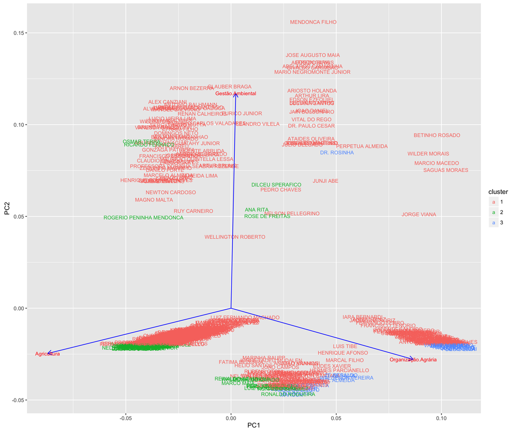

Analizando o gráfico da variaância explicada vemos que se removermos uma das variáveis do conjunto, haverá uma perda de aproximadamente 15% da informação.

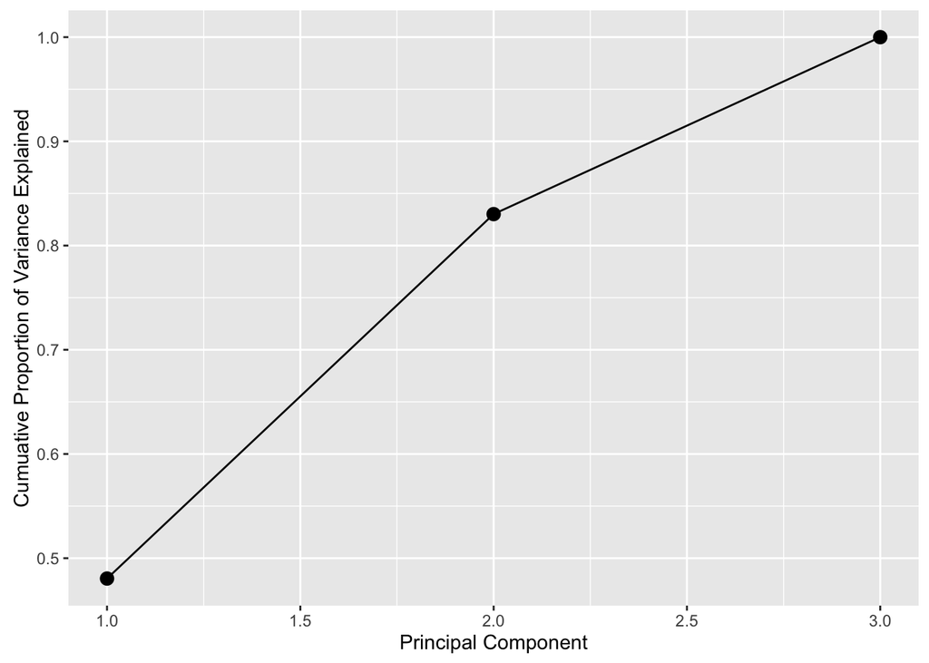

## t-SNE

[output not shown]

[interactive chart not shown]

## Resultados

Foi aplicado um kmeans com 3 grupos para colorir os gráficos.

- PCA

Após analizar as variáveis vimos que eles tem uma distribuição muito concentrada, praticamente exponencial. Por isso, antes de rodar o algoritmo foi aplicado o log + 1 em todas as variáveis para que a distribuicção se espalhe mais um pouco. PS: O +1 é para poder aplicar o log nas variáveis que são 0.

O resultado do PCA é bem interessante pois as variáveis formam eixos bem definidos, ou seja elas tem pouca relação enre si, outro fato interessante é que são formados grupos bem definidos. Com relação ao kmeans, vemos que os grupos formados não se mantem heterogênios no PCA, ou seja eles se misturam no gráfico.

- tSNE

O resultado do TSNE é um gráfico com um formato um tanto quanto peculiar, a formação de grupos não é tão nítida como é no PCA, porém podemos ver que os clusters formados no kmeans estão bem juntos no tSNE ao contrário do PCA.

- Opinião

Olhando para o gráfico do PCA dá pra ver que há uma polarização em torno da Agricultura e da Organizacção Agrária. Observamos também que o pessoal que investe em muito em gestão ambiental, tende a ser mais eclético e também investir em uma das duas áreas.

Nesse caso o PCA se mostrou mais informativo, pois eu consigo enxergar grupos com mais nítidez e dizer quais as variáveis que estão mais influenciando naquele determinado grupo. Acho o TSNE pode ser mais útil se tivermos uma quantidade maior de variáveis.

# Referencias

http://www.santanadoitarare.pr.gov.br/diariooficial/publicacoes/o_que_emenda_parlamentar.pdf

http://www.orcamentofederal.gov.br/glossario-1/emenda-de-comissao